# Tuesday Exercises

## Question 1

```r
setwd(dirname(rstudioapi::getActiveDocumentContext()$path))
calcium_data <- read.table(file="T3_3_Calcium.DAT", sep="")
calcium_data
```

```
##    V1 V2   V3   V4
## 1   1 35  3.5 2.80
## 2   2 35  4.9 2.70
## 3   3 40 30.0 4.38
## 4   4 10  2.8 3.21
## 5   5  6  2.7 2.73
## 6   6 20  2.8 2.81
## 7   7 35  4.6 2.88
## 8   8 35 10.9 2.90
## 9   9 35  8.0 3.28
## 10 10 30  1.6 3.20
```

```r
names(calcium_data) <- c("location","avail","exch","turnip-green-calc")
calcium_data
```

```
##    location avail exch turnip-green-calc
## 1         1    35  3.5              2.80
## 2         2    35  4.9              2.70
## 3         3    40 30.0              4.38
## 4         4    10  2.8              3.21
## 5         5     6  2.7              2.73
## 6         6    20  2.8              2.81
## 7         7    35  4.6              2.88
## 8         8    35 10.9              2.90
## 9         9    35  8.0              3.28
## 10       10    30  1.6              3.20
```

### (b)

```r
Sy <- cov(calcium_data[,2:4])
Sy
```

```
##                        avail      exch turnip-green-calc
## avail             140.544444 49.680000         1.9412222
## exch               49.680000 72.248444         3.6760889
## turnip-green-calc   1.941222  3.676089         0.2501211
```

```r
meany <- colMeans(calcium_data[,2:4])
meany
```

```
##             avail              exch turnip-green-calc
##            28.100             7.180             3.089
```

### (c)

Using equation 3.62: $\bar{z} = A\bar{y}$

```r
A <- matrix(c(1,1,1,2,-3,2,-1,-2,-3), nrow=3, ncol=3, byrow=TRUE)
z_bar <- A %*% meany
z_bar
```

```
##         [,1]
## [1,]  38.369
## [2,]  40.838
## [3,] -51.727
```

Computing the column means of a matrix containing the data of the observed z values:

```r
z <- t(A %*% t(as.matrix(calcium_data[,2:4])))
z_bar <- t(t(colMeans(z)))
z_bar
```

```
##         [,1]
## [1,]  38.369
## [2,]  40.838
## [3,] -51.727
```

### (d)

Using equation 3.64: $S_z= ASA^{'}$:

```r
s = A %*% Sy %*% t(A)
s
```

```
##           [,1]     [,2]      [,3]
## [1,]  323.6376  19.2526 -460.9770
## [2,]   19.2526 588.6710  104.0717
## [3,] -460.9770 104.0717  686.2697
```

By directly using the observed z values:

```r
s = cov(z)
s
```

```
##           [,1]     [,2]      [,3]
## [1,]  323.6376  19.2526 -460.9770
## [2,]   19.2526 588.6710  104.0717
## [3,] -460.9770 104.0717  686.2697
```

## Question 2

### (a)

```r
library(MASS)
library(scatterplot3d)
set.seed(548)
```

### (b)

```r
reactions <- data.frame(mvrnorm(n=80,
                               mu=c(40, 30, 30),
                               Sigma=matrix(c(12, 3, 3,
                                              3, 8, 3,
                                              3, 3, 9), ncol = 3)))
names(reactions) <- c("PercConvert", "PercUnchanged", "PercUnwant")
head(reactions, n=5)
```

```
##   PercConvert PercUnchanged PercUnwant
## 1    38.69584      29.34173   28.01419
## 2    38.64265      32.56998   30.65892
## 3    37.84826      28.43222   28.62671
## 4    41.51786      33.60033   30.54348
## 5    38.66333      28.82466   28.76605
```

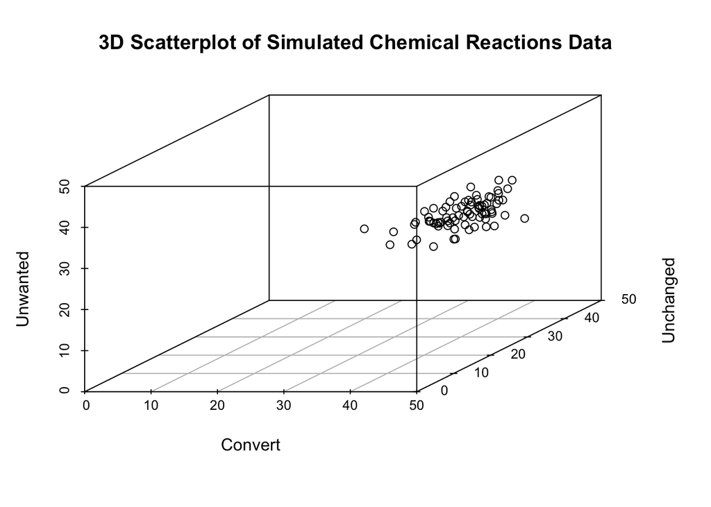

```r
scatterplot3d(reactions$PercConvert, reactions$PercUnchanged, reactions$PercUnwant,
              xlim=c(0,50), ylim=c(0,50), zlim=c(0,50),
              main="3D Scatterplot of Simulated Chemical Reactions Data",
              xlab="Convert", ylab="Unchanged", zlab="Unwanted")
```

```r
S <- var(reactions)
S
```

```
##               PercConvert PercUnchanged PercUnwant
## PercConvert     13.253240      4.215207   3.633787
## PercUnchanged    4.215207      8.719138   3.561002
## PercUnwant       3.633787      3.561002   6.935029
```

### (c)

```r
set.seed(368)
reactions1 <- data.frame(mvrnorm(n=80,
                               mu=c(40, 30, 30),
                               Sigma=matrix(c(40, 3, 3,
                                              3, 30, 3,
                                              3, 3, 36), ncol = 3)))
names(reactions1) <- c("PercConvert", "PercUnchanged", "PercUnwant")
head(reactions1, n=5)
```

```
##   PercConvert PercUnchanged PercUnwant
## 1    51.04764      33.12964   38.11479
## 2    38.26009      34.76181   26.59278
## 3    40.00580      23.58165   31.53468
## 4    35.74753      21.34839   30.73587
## 5    37.10502      33.34302   32.96978
```

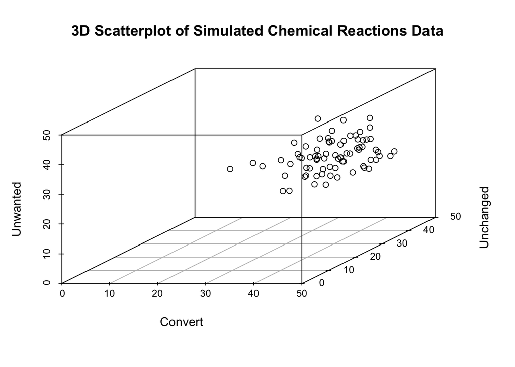

```r
scatterplot3d(reactions1$PercConvert, reactions1$PercUnchanged, reactions1$PercUnwant,
              xlim=c(0,50), ylim=c(0,50), zlim=c(0,50),
              main="3D Scatterplot of Simulated Chemical Reactions Data",
              xlab="Convert", ylab="Unchanged", zlab="Unwanted")
```

```r
S <- var(reactions1)
S
```

```
##               PercConvert PercUnchanged PercUnwant
## PercConvert     46.162297      4.183905   9.678358
## PercUnchanged    4.183905     29.490584   2.376736
## PercUnwant       9.678358      2.376736  22.821491
```

### (d)

The two graphs corroborate the generalized variances because each of them shows the distance between data points for each of the variables. The first simulated data had lower variances than the second data which is evident in the spread of the data points difference between the graphs.

### (e)

Comparing the magnitudes of the co-variances between the two simulated data sets, it can be observed that the values in the second data set are generally larger than the first one, per my reflection above. This could indicate that there is a stronger relationship between the variables in the second data set compared to the first one. There does seem to be a strength between pairs of variables such as PercConvert and PercUnwant as the variances are higher. The form overall of the matrix implies the strength and direction of the relationships between the pairs of variables in the data.

### (f)

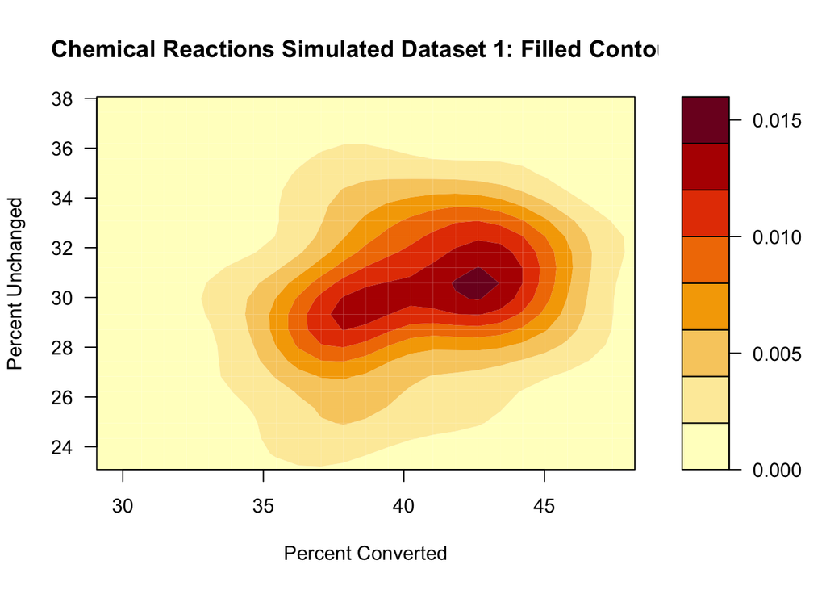

```r
z <- kde2d(reactions$PercConvert, reactions$PercUnchanged, n=25)
filled.contour(z, nlevels = 10,
               xlab="Percent Converted", ylab="Percent Unchanged",
               main="Chemical Reactions Simulated Dataset 1: Filled Contour")
```

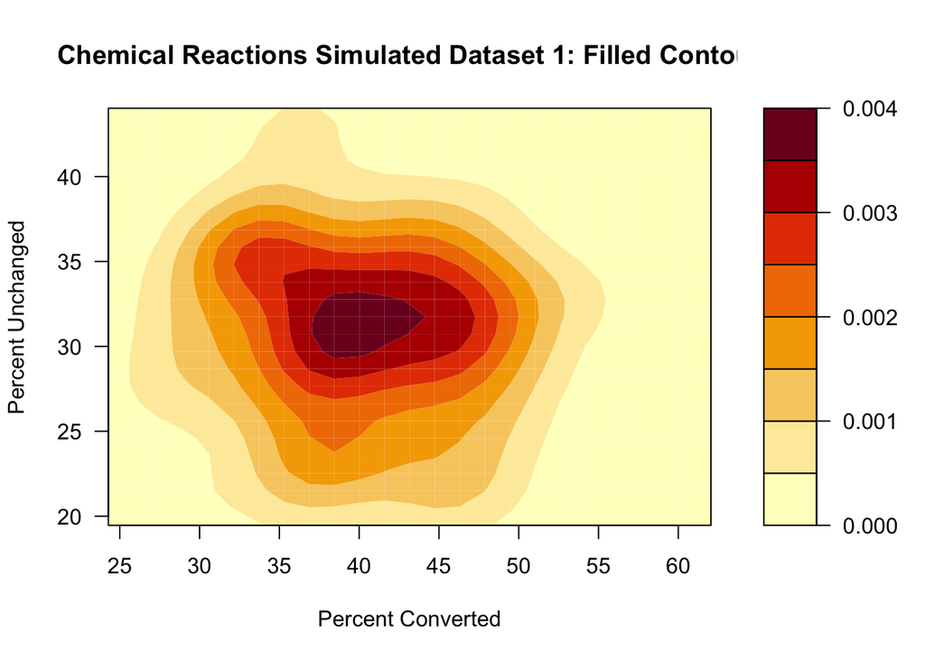

```r
z <- kde2d(reactions1$PercConvert, reactions1$PercUnchanged, n=25)
filled.contour(z, nlevels = 10,
               xlab="Percent Converted", ylab="Percent Unchanged",
               main="Chemical Reactions Simulated Dataset 1: Filled Contour")
```

From the contour plots, it seems that the center of the first data is higher than the second one. Also, the lines are much closer in the first plot, while in the second there are much greater gaps between lines. Compared the first data, there are a lot more data points that are concentrated in the center.

### (g)

#### (i)

```r
A <- matrix(c(1,1,1,
              1,-1,0), nrow=2, ncol=3, byrow=TRUE)
A
```

```
##      [,1] [,2] [,3]
## [1,]    1    1    1
## [2,]    1   -1    0
```

```r
z <- t(A %*% t(as.matrix(reactions1)))
z <- data.frame(z)
colnames(z) <- c("total", "diff")
```

#### (ii)

```r
z_bar <- t(colMeans(z))
z_bar
```

```
##         total     diff
## [1,] 100.6197 9.406085
```

These sample means make sense because they are the averages of the total and difference for converted and unchanged percentages of the data points in the z matrix. This means that the average of the total and difference of the data points in the z matrix is 100.6 and 9.4 respectively.

#### (iii)

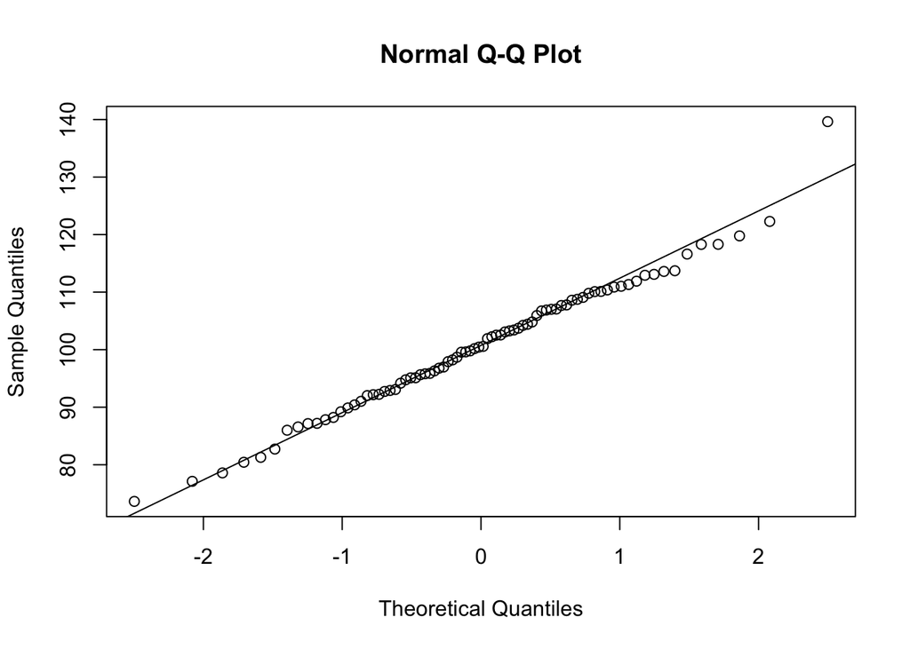

```r
qqnorm(z$total)
qqline(z$total)
```

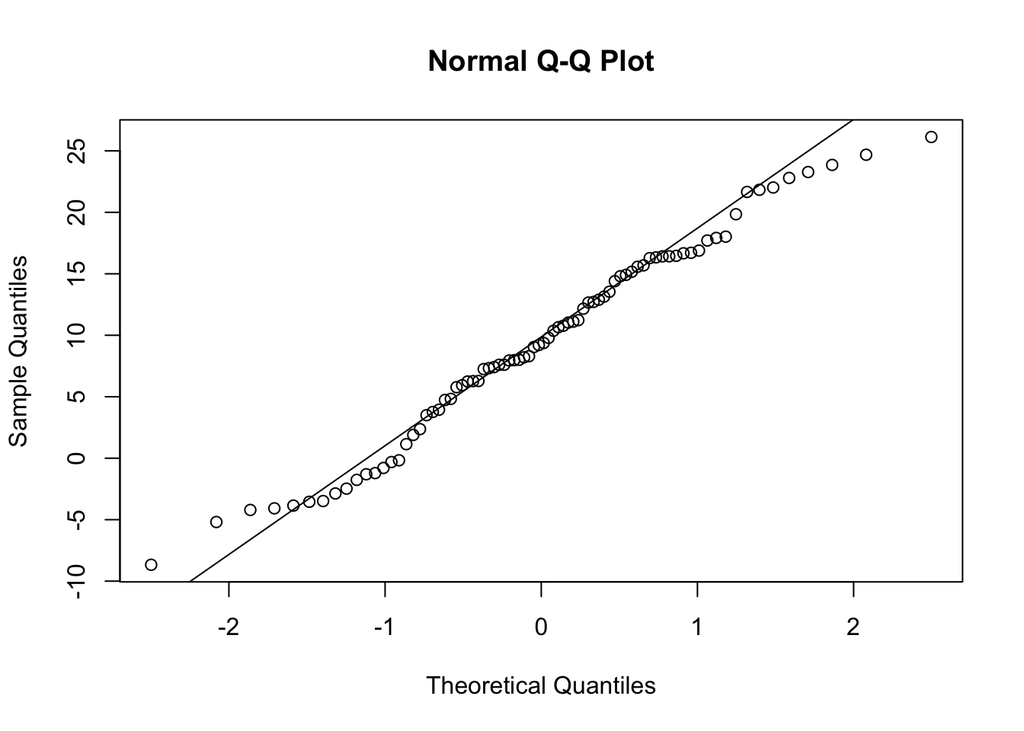

```r
qqnorm(z$diff)
qqline(z$diff)
```

The property of the MV normal distribution that this empirically confirms with the plots would be that each of the variables in z, total and diff follow a uni-variate normal distribution. Marginal normality is another name for this where each variable in the multivariate normal distribution follows a uni-variate normal distribution. So here each of the variables is approximately normally distributed on its own.

# Thursday Exercises

## Problem 1

### (a)

```r
setwd(dirname(rstudioapi::getActiveDocumentContext()$path))
probes <- read.table(file="T3_5_Probe.DAT", sep="")
probes
```

```
##    V1 V2 V3 V4 V5 V6
## 1   1 51 36 50 35 42
## 2   2 27 20 26 17 27
## 3   3 37 22 41 37 30
## 4   4 42 36 32 34 27
## 5   5 27 18 33 14 29
## 6   6 43 32 43 35 40
## 7   7 41 22 36 25 38
## 8   8 38 21 31 20 16
## 9   9 36 23 27 25 28
## 10 10 26 31 31 32 36
## 11 11 29 20 25 26 25
```

```r
names(probes) <- c("subject_no","y1","y2","y3","y4","y5")
probes
```

```
##    subject_no y1 y2 y3 y4 y5
## 1           1 51 36 50 35 42
## 2           2 27 20 26 17 27
## 3           3 37 22 41 37 30
## 4           4 42 36 32 34 27
## 5           5 27 18 33 14 29
## 6           6 43 32 43 35 40
## 7           7 41 22 36 25 38
## 8           8 38 21 31 20 16
## 9           9 36 23 27 25 28
## 10         10 26 31 31 32 36
## 11         11 29 20 25 26 25
```

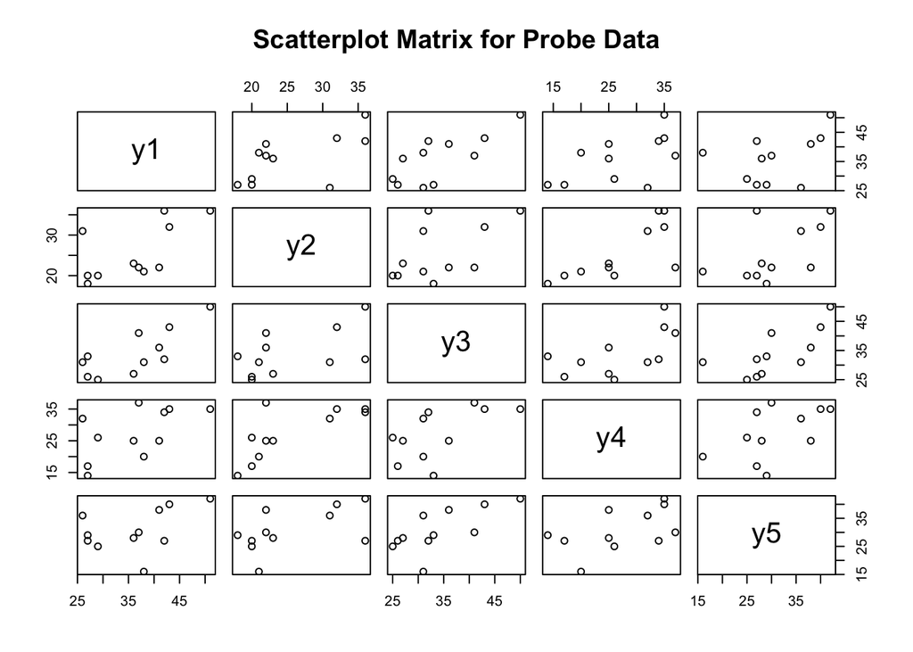

```r
pairs(probes[,2:6], main="Scatterplot Matrix for Probe Data")
```

It is quite difficult to see if there any egregious outliers in this data, but just looking at it in general there do seem to be some that deviate from a general pattern. This kind of plot is not perfectly reliable for identifying outliers in this situation. This is because it only provides insights into pairwise relationships between variables since it is limited to bivariate plots and outliers could occur in combinations of 3 or more variables. There is also the sense of subjectivity in this plot when determining and also that these can be influenced by the scale and distribution of the variables.

### (b)

```r
meany <- colMeans(probes[,2:6])
meany
```

```
##       y1       y2       y3       y4       y5
## 36.09091 25.54545 34.09091 27.27273 30.72727
```

The individual means of the 5 probe words are 36.09, 25.54, 34.09, 27.27, 30.727.

### (c)

```r
library(DescTools)
HotellingsT2Test(x=probes[,2:6], y = NULL, mu = c(30, 25, 40, 25, 30), test = "f")
```

```
##
##  Hotelling's one sample T2-test
##
## data:  probes[, 2:6]
## T.2 = 10.24, df1 = 5, df2 = 6, p-value = 0.0067
## alternative hypothesis: true location is not equal to c(30,25,40,25,30)
```

We do not reject the null hypothesis. There is not sufficient evidence to support that the mean response time for the 5 probe word positions is 30, 25, 40, 25, and 30 for the 5 words respectively. This is due to the p value 0.0067 > 0.001.

### (d)

```
## $multivariateNormality
##              Test        Statistic           p value Result
## 1 Mardia Skewness 34.4270153538093 0.495597767821439    YES
## 2 Mardia Kurtosis -1.2536620353529 0.209964872601331    YES
## 3             MVN             <NA>              <NA>    YES
##
## $univariateNormality
##               Test   Variable Statistic   p value Normality
## 1 Anderson-Darling subject_no    0.1466    0.9502    YES
## 2 Anderson-Darling     y1        0.3619    0.3758    YES
## 3 Anderson-Darling     y2        0.8349    0.0208    NO
## 4 Anderson-Darling     y3        0.3726    0.3530    YES
## 5 Anderson-Darling     y5        0.3442    0.4164    YES
##
## $Descriptives
##             n     Mean  Std.Dev Median Min Max 25th 75th       Skew   Kurtosis
## subject_no 11  6.00000 3.316625      6   1  11  3.5  8.5  0.0000000 -1.5289256
## y1         11 36.09091 8.067894     37  26  51 28.0 41.5  0.1886004 -1.2821930
## y2         11 25.54545 6.787689     22  18  36 20.5 31.5  0.5076445 -1.6110946
## y3         11 34.09091 7.790437     32  25  50 29.0 38.5  0.6467100 -0.8651606
## y5         11 30.72727 7.630084     29  16  42 27.0 37.0 -0.1535815 -0.9701041
```

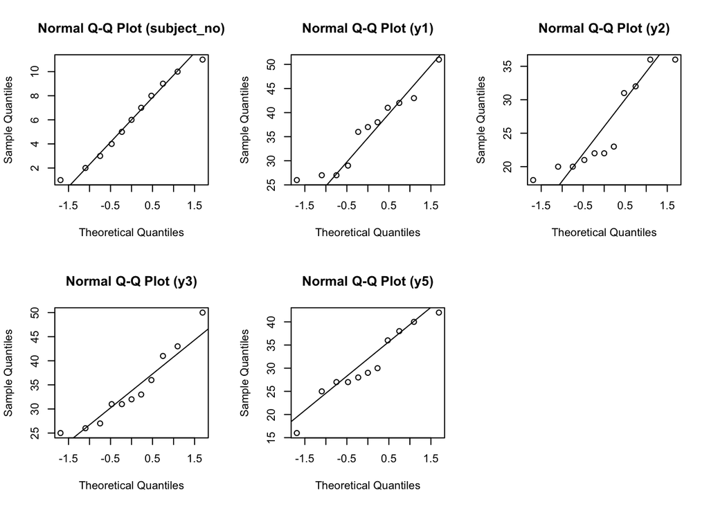

```r
library(MVN)
mvn(probes[,-5], univariatePlot="qqplot", mvnTest="mardia")
```

p-value is trustworthy as the there is not sufficient evidence to reject the null hypothesis that the data is multivariate normal.

### (e)

```r
t.test(x=probes$y1, mu=30)
```

```
##
##  One Sample t-test
##
## data:  probes$y1
## t = 2.5039, df = 10, p-value = 0.03124
## alternative hypothesis: true mean is not equal to 30
## 95 percent confidence interval:
##  30.67082 41.51099
## sample estimates:
## mean of x
##  36.09091
```

```r
t.test(x=probes$y2, mu=25)
```

```
##
##  One Sample t-test
##
## data:  probes$y2
## t = 0.26652, df = 10, p-value = 0.7953
## alternative hypothesis: true mean is not equal to 25
## 95 percent confidence interval:
##  20.98542 30.10549
## sample estimates:
## mean of x
##  25.54545
```

```r
t.test(x=probes$y3, mu=40)
```

```
##
##  One Sample t-test
##
## data:  probes$y3
## t = -2.5157, df = 10, p-value = 0.03061
## alternative hypothesis: true mean is not equal to 40
## 95 percent confidence interval:
##  28.85722 39.32460
## sample estimates:
## mean of x
##  34.09091
```

```r
t.test(x=probes$y4, mu=25)
```

```
##
##  One Sample t-test
##
## data:  probes$y4
## t = 0.95104, df = 10, p-value = 0.364
## alternative hypothesis: true mean is not equal to 25
## 95 percent confidence interval:
##  21.94811 32.59735
## sample estimates:
## mean of x
##  27.27273
```

```r
t.test(x=probes$y5, mu=30)
```

```
##
##  One Sample t-test
##
## data:  probes$y5
## t = 0.31613, df = 10, p-value = 0.7584
## alternative hypothesis: true mean is not equal to 30
## 95 percent confidence interval:
##  25.60131 35.85323
## sample estimates:
## mean of x
##  30.72727
```

From these univariate hypothesis tests it seems that for all of the variables that there is not sufficient evidence to reject the null hypothesis that the true mean is equal to null hypothesized mean. To conclude the means from the null hypothesis from part (b) seem to be in line with the individual means of the 5 probe word response times.

## Problem 2

### (a)

```r
set.seed(132)
sim <- data.frame(mvrnorm(n=50,
                               mu=c(100, 100, 100, 100),
                               Sigma=matrix(c(15^2, 0, 0, 0,
                                              0, 15^2, 0, 0,
                                              0, 0, 15^2, 0,
                                              0, 0, 0, 15^2), ncol = 4)))
meany <- colMeans(sim)
meany
```

```
##        X1        X2        X3        X4
## 102.85811  98.82478 101.70576 101.36992
```

My 4 sample means that I got were 102.85, 98.82, 101.70, 101.36.

```r
HotellingsT2Test(x=sim, y = NULL, mu = c(100, 100, 100, 100), test = "f")
```

```
##
##  Hotelling's one sample T2-test
##
## data:  sim
## T.2 = 0.77331, df1 = 4, df2 = 46, p-value = 0.5482
## alternative hypothesis: true location is not equal to c(100,100,100,100)
```

The p-value is 0.5482 and the conclusion when testing this null would be that we would not reject the null hypothesis. The hypothesized means would corroborate with the sample means and I am not surprised by this conclusion because the computed means are very close to the hypothesized means.

```r
HotellingsT2Test(x=sim, y = NULL, mu = c(98, 98, 98, 98), test = "f")
```

```
##
##  Hotelling's one sample T2-test
##
## data:  sim
## T.2 = 2.7349, df1 = 4, df2 = 46, p-value = 0.04007
## alternative hypothesis: true location is not equal to c(98,98,98,98)
```

```r
HotellingsT2Test(x=sim, y = NULL, mu = c(95, 95, 95, 95), test = "f")
```

```
##
##  Hotelling's one sample T2-test
##
## data:  sim
## T.2 = 8.8976, df1 = 4, df2 = 46, p-value = 2.082e-05
## alternative hypothesis: true location is not equal to c(95,95,95,95)
```

From these 3 tests that we have been asked to perform the take-home message is that when all variables are 50 linearly independent of one another the mean of the sample is very close to the population mean. As it can be seen that when all of them are 100 then the p value is high but when all are reduced then the p value is greatly reduced.

### (b)

```r
set.seed(256)
sim <- data.frame(mvrnorm(n=10,
                               mu=c(100, 100, 100, 100),
                               Sigma=matrix(c(15^2, 0, 0, 0,
                                              0, 15^2, 0, 0,
                                              0, 0, 15^2, 0,
                                              0, 0, 0, 15^2), ncol = 4)))
HotellingsT2Test(x=sim, y = NULL, mu = c(98, 98, 98, 98), test = "f")
```

```
##
##  Hotelling's one sample T2-test
##
## data:  sim
## T.2 = 3.6996, df1 = 4, df2 = 6, p-value = 0.07525
## alternative hypothesis: true location is not equal to c(98,98,98,98)
```

Comparing the results from (a), the p-value 0.07 rather than 0.04 and the conclusion would be the same. The message would probably be that when the sample size is large enough then the mean of the sample is the mean of the population.

### (c)

```r
set.seed(643)
sim <- data.frame(mvrnorm(n=50,
                               mu=c(100, 100, 100, 100),
                               Sigma=matrix(c(20^2, 0, 0, 0,
                                              0, 20^2, 0, 0,
                                              0, 0, 20^2, 0,
                                              0, 0, 0, 20^2), ncol = 4)))
HotellingsT2Test(x=sim, y = NULL, mu = c(98, 98, 98, 98), test = "f")
```

```
##
##  Hotelling's one sample T2-test
##
## data:  sim
## T.2 = 1.1508, df1 = 4, df2 = 46, p-value = 0.3448
## alternative hypothesis: true location is not equal to c(98,98,98,98)
```

### (d)

The ability of the Hotelling’s T^2-test to detect that observed data deviates from what would be expected if the null hypothesis were true depends on 3 things, namely the sample size, the distance of the observed data from the hypothesized means, and the variance of the data.